# **IMPORTANT** instruction for Problem 1: You should replace the 2D aneurysm dataset with a “spatiotemporal” dataset (scalar or vector) from your own research or lab (or an online database as explained below). Make sure you have at least 20 time-steps (ideally at least 40). If you have 3D data you can slice through it to make it 2D. You can use the aneurysm data explained below and uploaded mat file to see how to structure your data (similar to the data matrix in lectures). If you do not have any spatiotemporal data in your research group (justify why not!) then you can use the aneurysm data.

# **Bonus point** **(Data Curation)**: Online open-source datasets are ubiquitous these days. Search online to find a spatiotemporal dataset with the temporal resolution requirement above. The dataset should be related to a physical system and ideally of interest to you. Explain (document) the dataset and use it for Problem 1 below. Share the raw dataset, link to where you found it, and make it in mat format where columns are time and rows are space (similar to the sample Aneurysm dataset). 10% bonus on the exam that could be transferred to your entire course grade if you get above 100

# NOTE: I did the code initially for the aneurysm data set for practice and to get an idea of the approach to then apply the solutions to my own data set. My dataset is spatiotemporal data of how motors actuate as a function of distance of a system and acceleration outputs in x, y, and z axis.

# 1. We are given data matrix for blood flow velocity in a 2D aneurysm. The data is stored in 2D velocity vector aneu.mat. The velocity array is our typical spatiotemporal data matrix and has 3943 points and 49 time-steps (Note that this is vector data so the number of rows is 2*3943=7886). Each row first contains the x component of the velocity vector then the y component of velocity and then goes to the x and y component of the next spatial point. The coordinates array shows you the x and y coordinate position of these spatial points in the same order (useful for plotting your data). You can plot the data (e.g., velocity magnitude) using scatter plot (make sure you play with the range of colorbar to see features inside the aneurysm where the flow is very slow).

# Perform PCA (POD) on this data. Note that you can either work in vector format (no need to change the data matrix) or if you are just interested in velocity magnitude you can first pre-process the data to calculate velocity magnitude at each of the 3943 points, reduce the data matrix, and then perform PCA.

```
Keys in .mat: dict_keys(['__header__', '__version__', '__globals__', 'Coordinates', 'velocity'])
Coordinates shape: (3943, 2)
Velocity shape (raw): (7886, 49)
Velocity shape (used): (7886, 49)
```

```
interactive(children=(IntSlider(value=0, description='k', max=48), Output()), _dom_classes=('widget-interact',…
```

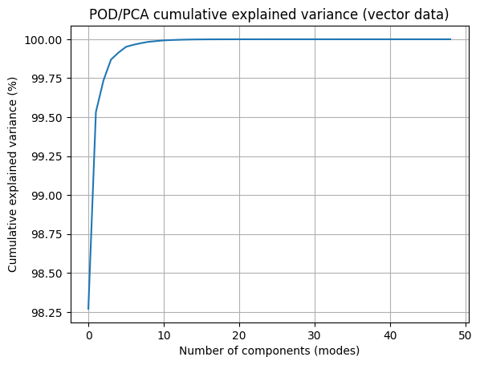

```
pca.components_.shape: (49, 7886)
```

```python
from scipy.io import loadmat
import numpy as np
import matplotlib.pyplot as plt
from ipywidgets import interact, IntSlider
from sklearn.decomposition import PCA

# Load .mat
mat_data = loadmat('2D_velocity_vector_aneu.mat')
print("Keys in .mat:", mat_data.keys())

coordinates = mat_data['Coordinates']   # expected (3943, 2)
velocity = mat_data['velocity']         # expected (7886, 49) or possibly (49, 7886)

print('Coordinates shape:', coordinates.shape)
print('Velocity shape (raw):', velocity.shape)

# Ensure velocity is (7886, 49): rows=stacked DOFs (u1,v1,u2,v2,...)
if velocity.shape[0] == 49 and velocity.shape[1] == 7886:
    velocity = velocity.T

print('Velocity shape (used):', velocity.shape)

num_points = coordinates.shape[0]
assert velocity.shape[0] == 2 * num_points, "Velocity rows should be 2*num_points (u,v stacked)."

# Split u/v from stacked rows
u = velocity[0::2, :]   # (3943, 49)
v = velocity[1::2, :]   # (3943, 49)

# Velocity magnitude at each point/time
velocity_magnitude = np.sqrt(u**2 + v**2)  # (3943, 49)

# Scatter slider to view time snapshots
x = coordinates[:, 0]
y = coordinates[:, 1]

# Use a fixed color scale across time so frames are comparable
vmin = 0.0
vmax = np.percentile(velocity_magnitude, 95)

def show_frame(k):
    plt.figure()
    sc = plt.scatter(x, y, c=velocity_magnitude[:, k], s=8, cmap='inferno',
                     vmin=vmin, vmax=vmax, linewidths=0)
    plt.colorbar(sc, label='|v|')
    plt.title(f'Velocity magnitude at time step {k}')
    plt.xlabel('x'); plt.ylabel('y')
    plt.axis('equal')
    plt.show()

interact(show_frame, k=IntSlider(min=0, max=velocity_magnitude.shape[1]-1, step=1, value=0))

# POD/PCA (vector form): snapshots are samples (time), stacked DOFs are features
# X shape: (Nt, 2*num_points) = (49, 7886)
X = velocity.T
Xc = X - X.mean(axis=0, keepdims=True)  # mean-center over time

pca = PCA()
pca.fit(Xc)

# Cumulative explained variance (energy)
plt.figure()
plt.plot(np.cumsum(pca.explained_variance_ratio_) * 100)
plt.xlabel('Number of components (modes)')
plt.ylabel('Cumulative explained variance (%)')
plt.title('POD/PCA cumulative explained variance (vector data)')
plt.grid(True)
plt.show()

print("pca.components_.shape:", pca.components_.shape)  # should be (49, 7886)
```

## (a). Plot the first three dominant modes (velocity magnitude or vector). Set the min and max of the colorbar so you see flow features inside the aneurysm. Note that in practice forvisualization, we plot over an unstructured grid not scatter points, but here we will plot on scatter points to make the process easier. However, please do investigate and see how you can improve your simple visualization based on what you find and your data.

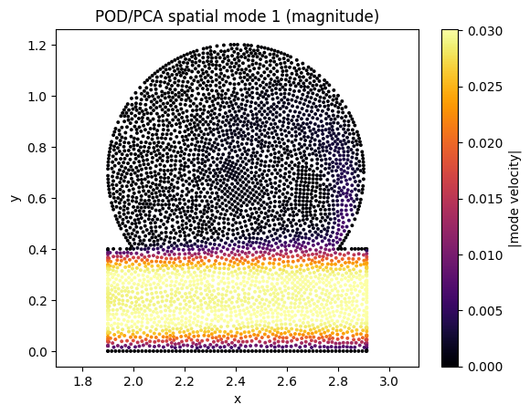

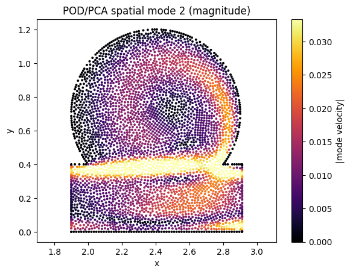

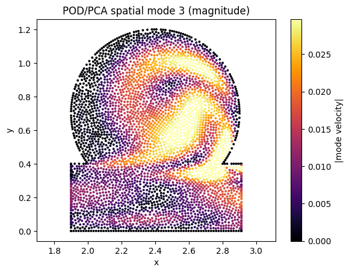

```
interactive(children=(IntSlider(value=0, description='mode_idx', max=48), Output()), _dom_classes=('widget-int…
```

```
<function __main__.show_mode(mode_idx)>
```

```python
# Plot the first three dominant spatial modes (magnitude of vector mode)

import numpy as np
import matplotlib.pyplot as plt
from ipywidgets import interact, IntSlider

def show_mode(mode_idx):
    # Grab the mode as a vector over stacked DOFs (length 2*num_points)
    mode_vec = pca.components_[mode_idx]                 # (7886,)
    mode_uv  = mode_vec.reshape(num_points, 2)           # (3943, 2) -> [u_mode, v_mode]
    mode_mag = np.sqrt(mode_uv[:, 0]**2 + mode_uv[:, 1]**2)

    # Use a mode-specific color range to reveal slow-flow structure
    m_vmin = 0.0
    m_vmax = np.percentile(mode_mag, 95)

    plt.figure()
    sc = plt.scatter(x, y, c=mode_mag, s=8, cmap='inferno',
                     vmin=m_vmin, vmax=m_vmax, linewidths=0)
    plt.colorbar(sc, label='|mode velocity|')
    plt.title(f'POD/PCA spatial mode {mode_idx + 1} (magnitude)')
    plt.xlabel('x'); plt.ylabel('y')
    plt.axis('equal')
    plt.show()

# create first three modes
for mode_idx in range(3):
    show_mode(mode_idx)

# make interactive slider for all modes
interact(show_mode, mode_idx=IntSlider(min=0, max=48, step=1, value=0))
```

## (b). Corrupt your data in two different approaches: 1- Adding noise randomly to 80% of your data. 2- Adding noise to a local specific region (use coordinates to know the location). When you add noise you generate a random number with zero mean and standard deviation 1 from a Gaussian distribution, then you modify each data entry as: xnoisy = x+ζ∗rand∗x, where rand is the random number you generated and ζ is the level of noise. Play with different noise levels (0.05, 0.1, 0.2, etc.). As an example, ζ = 0.1 is adding 10% noise (we disturb the data by around 10% of its value with some randomness). Similar to the lecture 9 plots, for each noise level and pattern you investigated plot the singular values sorted versus mode as well as the cumulative energy (for each mode this is the sum of all singular values up to that mode normalized by the sum of all singular values). Comment on what you learn.

```
Local region bounds:
  x in (np.float64(2.2540430249999996), np.float64(2.5575084749999997))
  y in (np.float64(0.41998425), np.float64(0.77997075))
Points in region: 388 / 3943 (9.8%)
```

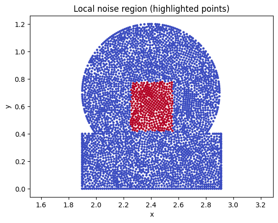

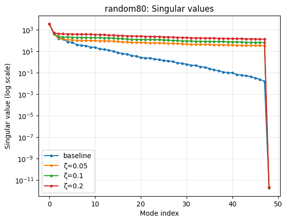

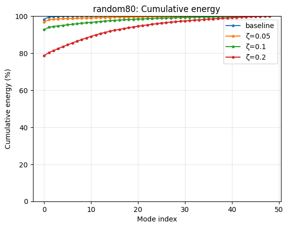

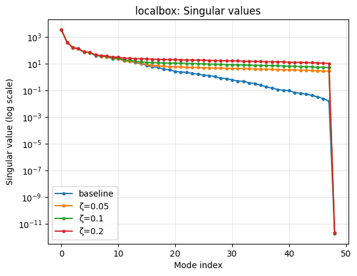

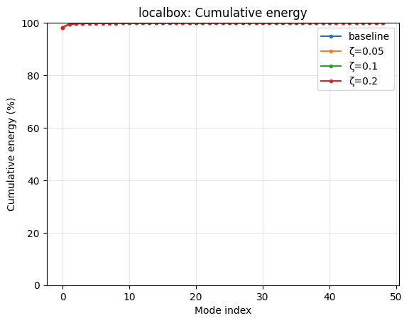

```python
# Corrupt data in two ways + plot singular values & cumulative energy for multiple noise level

import numpy as np
import matplotlib.pyplot as plt

# X is (Nt, 2*num_points) = (49, 7886) from Cell 1
# coordinates is (num_points, 2)
# num_points defined in Cell 1

def svd_energy_curves(Xsnap_centered):
    """
    Compute singular values and cumulative energy curve for centered snapshot matrix.
    Xsnap_centered shape: (Nt, Ndof)
    Returns:
      S: singular values (sorted descending by default from SVD)
      cum_energy: cumulative energy fraction based on S^2
    """
    # SVD on centered data matrix
    Uc, S, Vhc = np.linalg.svd(Xsnap_centered, full_matrices=False)
    energy = (S**2) / np.sum(S**2)
    cum_energy = np.cumsum(energy)
    return S, cum_energy


def add_noise_to_mask(Xbase, mask, zeta, rng):
    """
    Apply multiplicative noise to selected entries:
        x_noisy = x + zeta * rand * x
    where rand ~ N(0,1).
    Xbase shape: (Nt, Ndof)
    mask same shape: True where noise is applied
    """
    rand = rng.standard_normal(size=Xbase.shape)
    Xnoisy = Xbase.copy()
    Xnoisy[mask] = Xbase[mask] + zeta * rand[mask] * Xbase[mask]
    return Xnoisy


def build_random_mask(shape, frac, rng):
    """Boolean mask with 'frac' fraction of entries set to True."""
    return rng.random(shape) < frac


def build_local_region_mask(coords, Xshape, x_bounds, y_bounds):
    """
    Build a mask that applies noise to *all time steps* but only to spatial points
    inside a coordinate box. Because X is vector DOFs (u,v stacked), we include
    both u and v DOFs for points in the region.

    coords shape: (num_points, 2)
    Xshape: (Nt, 2*num_points)
    x_bounds: (xmin, xmax)
    y_bounds: (ymin, ymax)
    """
    Nt, Ndof = Xshape
    x = coords[:, 0]
    y = coords[:, 1]
    in_region = (x >= x_bounds[0]) & (x <= x_bounds[1]) & (y >= y_bounds[0]) & (y <= y_bounds[1])

    # Convert point-mask (length num_points) to DOF-mask (length 2*num_points)
    dof_mask = np.zeros(2 * num_points, dtype=bool)
    dof_mask[0::2] = in_region  # u
    dof_mask[1::2] = in_region  # v

    # Apply to all time steps
    mask = np.tile(dof_mask, (Nt, 1))
    return mask, in_region


def plot_svd_results(S_list, CE_list, labels, title_prefix):
    """
    Plot singular values and cumulative energy curves.
    S_list: list of arrays of singular values
    CE_list: list of arrays of cumulative energy
    labels: list of strings
    """
    # Singular values (log scale helps)
    plt.figure()
    for S, lab in zip(S_list, labels):
        plt.plot(S, marker='o', linestyle='-', markersize=3, label=lab)
    plt.yscale('log')
    plt.xlabel('Mode index')
    plt.ylabel('Singular value (log scale)')
    plt.title(f'{title_prefix}: Singular values')
    plt.grid(True, which='both', alpha=0.3)
    plt.legend()
    plt.show()

    # Cumulative energy
    plt.figure()
    for ce, lab in zip(CE_list, labels):
        plt.plot(ce * 100, marker='o', linestyle='-', markersize=3, label=lab)
    plt.xlabel('Mode index')
    plt.ylabel('Cumulative energy (%)')
    plt.title(f'{title_prefix}: Cumulative energy')
    plt.grid(True, alpha=0.3)
    plt.ylim(0, 100)
    plt.legend()
    plt.show()


# Baseline (no noise)
Xc_base = X - X.mean(axis=0, keepdims=True)
S0, ce0 = svd_energy_curves(Xc_base)

# Noise experiments
zetas = [0.05, 0.10, 0.20]  # you can add more
rng = np.random.default_rng(0)  # reproducible

# Randomly add noise to 80% of entries
frac_corrupt = 0.80
random_masks = {z: build_random_mask(X.shape, frac_corrupt, rng) for z in zetas}

# Add noise to a local region (choose a box in the coordinate domain)
xmin, xmax = coordinates[:, 0].min(), coordinates[:, 0].max()
ymin, ymax = coordinates[:, 1].min(), coordinates[:, 1].max()

# central-ish box (middle 30% of x and y range)
x_bounds = (xmin + 0.35*(xmax-xmin), xmin + 0.65*(xmax-xmin))
y_bounds = (ymin + 0.35*(ymax-ymin), ymin + 0.65*(ymax-ymin))

local_mask, in_region_points = build_local_region_mask(coordinates, X.shape, x_bounds, y_bounds)

print("Local region bounds:")
print("  x in", x_bounds)
print("  y in", y_bounds)
print(f"Points in region: {in_region_points.sum()} / {num_points} ({100*in_region_points.mean():.1f}%)")

# visualize the chosen noisy region
plt.figure()
plt.scatter(coordinates[:,0], coordinates[:,1], s=6, c=in_region_points.astype(int), cmap='coolwarm')
plt.title("Local noise region (highlighted points)")
plt.xlabel("x"); plt.ylabel("y")
plt.axis("equal")
plt.show()

# Run and plot for each corruption type
for pattern in ["random80", "localbox"]:
    S_list = [S0]
    CE_list = [ce0]
    labels = ["baseline"]

    for z in zetas:
        if pattern == "random80":
            mask = random_masks[z]
            Xnoisy = add_noise_to_mask(X, mask, z, rng)
            title_prefix = f"Noise pattern: random 80% (ζ={z})"
            lab = f"ζ={z}"
        else:
            Xnoisy = add_noise_to_mask(X, local_mask, z, rng)
            title_prefix = f"Noise pattern: local region (ζ={z})"
            lab = f"ζ={z}"

        # Center over time (same preprocessing as baseline)
        Xc = Xnoisy - Xnoisy.mean(axis=0, keepdims=True)

        S, ce = svd_energy_curves(Xc)
        S_list.append(S)
        CE_list.append(ce)
        labels.append(lab)

    # For each pattern, plot all zetas + baseline together
    plot_svd_results(S_list, CE_list, labels, title_prefix=pattern)
```

## (c). Perform RPCA and repeat the above to see how RPCA improves your results under noise (you might need to play with the hyperparameter λ in RPCA). Report on RPCA’s performance based on noise level and pattern (random vs. localized)

```
Local region bounds:
  x in (np.float64(2.2540430249999996), np.float64(2.5575084749999997))
  y in (np.float64(0.41998425), np.float64(0.77997075))
Points in region: 388 / 3943 (9.8%)
```

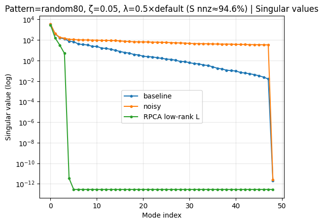

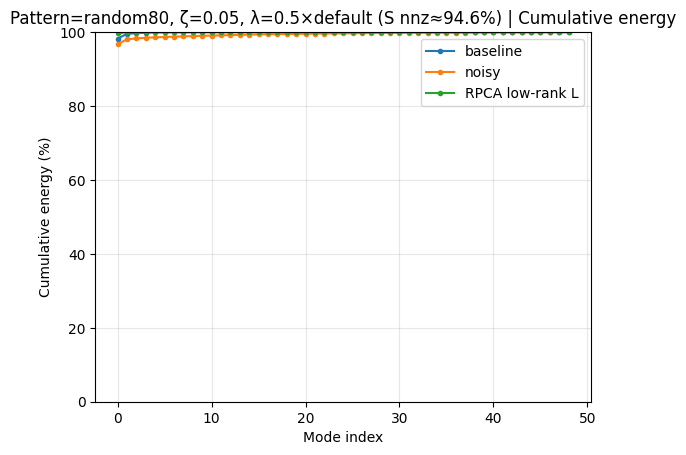

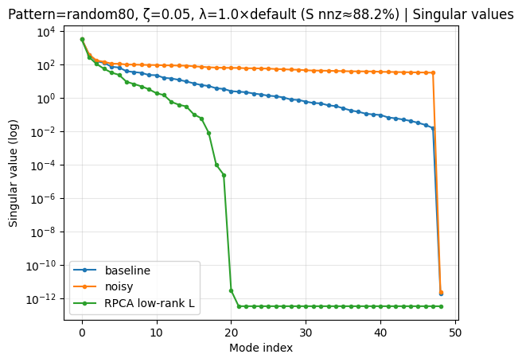

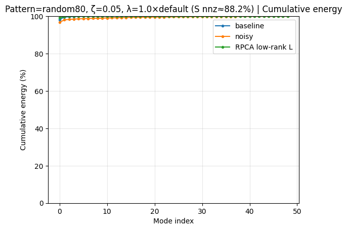

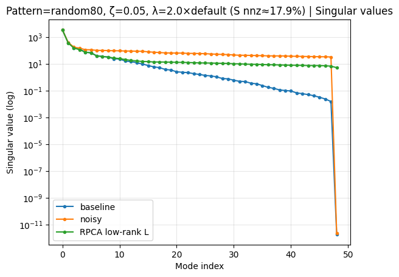

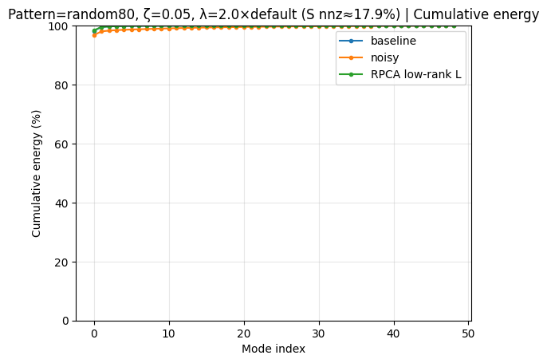

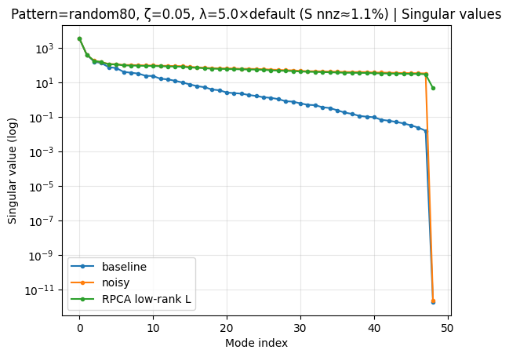

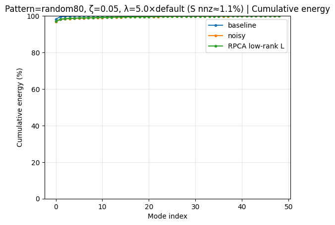

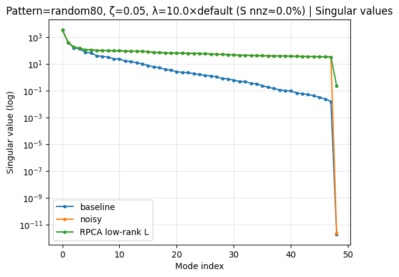

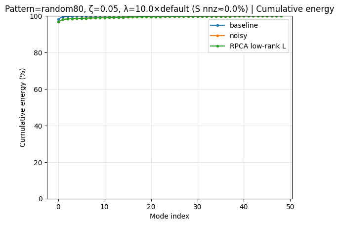

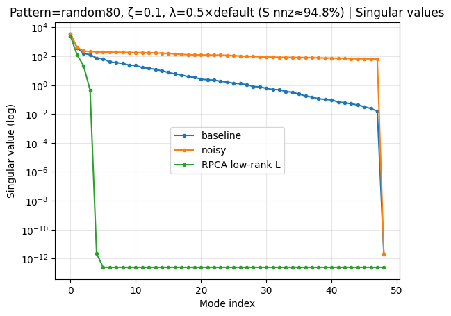

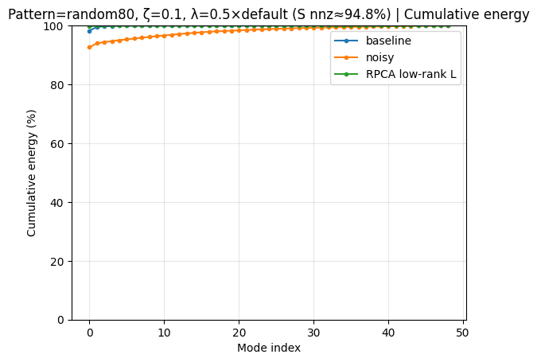

[48 more figures not shown]

```python
import numpy as np
import matplotlib.pyplot as plt

assert 'X' in globals(), "Run Cell 1 first (needs X)."
assert 'coordinates' in globals(), "Run Cell 1 first (needs coordinates)."
assert 'num_points' in globals(), "Run Cell 1 first (needs num_points)."

# RPCA via Inexact Augmented Lagrange Multiplier (IALM)

def soft_threshold(X, tau):
    return np.sign(X) * np.maximum(np.abs(X) - tau, 0.0)

def svt(X, tau):
    # Singular Value Thresholding: U diag(max(s - tau, 0)) Vh
    U, s, Vh = np.linalg.svd(X, full_matrices=False)
    s_thresh = np.maximum(s - tau, 0.0)
    return (U * s_thresh) @ Vh

def rpca_ialm(D, lam=None, tol=1e-7, max_iter=500, verbose=False):
    """
    D: (m, n) data matrix
    lam: lambda parameter; default 1/sqrt(max(m,n))
    returns L, S
    """
    m, n = D.shape
    if lam is None:
        lam = 1.0 / np.sqrt(max(m, n))

    # Initialize
    L = np.zeros_like(D)
    S = np.zeros_like(D)

    # Dual variable
    Y = D / max(np.linalg.norm(D, 2), np.linalg.norm(D.ravel(), np.inf) / lam + 1e-12)

    # mu schedule (common heuristic)
    mu = 1.25 / (np.linalg.norm(D, 2) + 1e-12)
    mu_bar = mu * 1e7
    rho = 1.5

    D_norm = np.linalg.norm(D, 'fro') + 1e-12

    for it in range(max_iter):
        # Update low-rank part via SVT
        L = svt(D - S + (1.0/mu)*Y, 1.0/mu)

        # Update sparse part via soft-thresholding
        S = soft_threshold(D - L + (1.0/mu)*Y, lam/mu)

        # Update dual
        Z = D - L - S
        Y = Y + mu * Z

        # Convergence check
        err = np.linalg.norm(Z, 'fro') / D_norm
        if verbose and (it % 25 == 0 or it == max_iter-1):
            nnz = np.mean(np.abs(S) > 1e-12) * 100
            print(f"iter={it:4d}  rel_err={err:.2e}  S_nnz={nnz:.1f}%  mu={mu:.2e}")

        if err < tol:
            break

        mu = min(mu * rho, mu_bar)

    return L, S


# Helpers to compute & plot spectra
def svd_energy_curves(Xsnap_centered):
    # Xsnap_centered shape: (Nt, Ndof)
    _, S, _ = np.linalg.svd(Xsnap_centered, full_matrices=False)
    energy = (S**2) / np.sum(S**2)
    cum_energy = np.cumsum(energy)
    return S, cum_energy

def add_noise_to_mask(Xbase, mask, zeta, rng):
    rand = rng.standard_normal(size=Xbase.shape)
    Xnoisy = Xbase.copy()
    Xnoisy[mask] = Xbase[mask] + zeta * rand[mask] * Xbase[mask]
    return Xnoisy

def build_random_mask(shape, frac, rng):
    return rng.random(shape) < frac

def build_local_region_mask(coords, Xshape, x_bounds, y_bounds, num_points):
    Nt, Ndof = Xshape
    x = coords[:, 0]
    y = coords[:, 1]
    in_region = (x >= x_bounds[0]) & (x <= x_bounds[1]) & (y >= y_bounds[0]) & (y <= y_bounds[1])

    dof_mask = np.zeros(2 * num_points, dtype=bool)
    dof_mask[0::2] = in_region
    dof_mask[1::2] = in_region

    mask = np.tile(dof_mask, (Nt, 1))
    return mask, in_region

def plot_compare_spectra(S_base, CE_base, S_noisy, CE_noisy, S_rpca, CE_rpca, title):
    # Singular values
    plt.figure()
    plt.plot(S_base, 'o-', markersize=3, label='baseline')
    plt.plot(S_noisy, 'o-', markersize=3, label='noisy')
    plt.plot(S_rpca, 'o-', markersize=3, label='RPCA low-rank L')
    plt.yscale('log')
    plt.xlabel('Mode index')
    plt.ylabel('Singular value (log)')
    plt.title(title + " | Singular values")
    plt.grid(True, which='both', alpha=0.3)
    plt.legend()
    plt.show()

    # Cumulative energy
    plt.figure()
    plt.plot(CE_base*100, 'o-', markersize=3, label='baseline')
    plt.plot(CE_noisy*100, 'o-', markersize=3, label='noisy')
    plt.plot(CE_rpca*100, 'o-', markersize=3, label='RPCA low-rank L')
    plt.xlabel('Mode index')
    plt.ylabel('Cumulative energy (%)')
    plt.title(title + " | Cumulative energy")
    plt.grid(True, alpha=0.3)
    plt.ylim(0, 100)
    plt.legend()
    plt.show()

# Baseline spectra (centered)
Xc_base = X - X.mean(axis=0, keepdims=True)
S0, CE0 = svd_energy_curves(Xc_base)

# Noise patterns + levels
zetas = [0.05, 0.10, 0.20]
rng = np.random.default_rng(0)

# random 80% corruption
frac_corrupt = 0.80
random_masks = {z: build_random_mask(X.shape, frac_corrupt, rng) for z in zetas}

# localized region corruption (box in middle of domain)
xmin, xmax = coordinates[:, 0].min(), coordinates[:, 0].max()
ymin, ymax = coordinates[:, 1].min(), coordinates[:, 1].max()

x_bounds = (xmin + 0.35*(xmax-xmin), xmin + 0.65*(xmax-xmin))
y_bounds = (ymin + 0.35*(ymax-ymin), ymin + 0.65*(ymax-ymin))

local_mask, in_region_points = build_local_region_mask(coordinates, X.shape, x_bounds, y_bounds, num_points)

print("Local region bounds:")
print("  x in", x_bounds)
print("  y in", y_bounds)
print(f"Points in region: {in_region_points.sum()} / {num_points} ({100*in_region_points.mean():.1f}%)")

# RPCA hyperparameter lambda
lam_multipliers = [0.5, 1.0, 2.0, 5.0, 10.0]  # you can adjust

# Run experiments
for pattern_name, mask_dict in [
    ("random80", random_masks),
    ("localbox", {z: local_mask for z in zetas})
]:
    for z in zetas:
        # Build noisy data
        mask = mask_dict[z]
        Xnoisy = add_noise_to_mask(X, mask, z, rng)

        # Center the noisy data the same way (over time)
        Xc_noisy = Xnoisy - Xnoisy.mean(axis=0, keepdims=True)

        # Noisy spectra
        S_noisy, CE_noisy = svd_energy_curves(Xc_noisy)

        # Try a few lambdas and plot each result
        m, n = Xc_noisy.shape
        lam_default = 1.0 / np.sqrt(max(m, n))

        for mult in lam_multipliers:
            lam = mult * lam_default

            # RPCA decomposition on centered noisy data
            L, S_sparse = rpca_ialm(Xc_noisy, lam=lam, tol=1e-7, max_iter=300, verbose=False)

            # Spectra of low-rank component
            S_rpca, CE_rpca = svd_energy_curves(L)

            # How sparse did RPCA make S
            sparsity = np.mean(np.abs(S_sparse) > 1e-12) * 100

            title = f"Pattern={pattern_name}, ζ={z}, λ={mult:.1f}×default (S nnz≈{sparsity:.1f}%)"
            plot_compare_spectra(S0, CE0, S_noisy, CE_noisy, S_rpca, CE_rpca, title)
```